# Lecture 15 - Theory and Homework

This is an [R Markdown](http://rmarkdown.rstudio.com) Notebook

### Lecture 15 - Unsupervised Machine Learning

#### Data import for the exercise:

```r
library(tidyverse)
library(plyr)
# data frame containing information from multiple sensors
DF_Data <- read_csv("DF_Data.csv")
# data frame containing equipment information
DF_Equipm <- read_csv("DF_EquipmData.csv")
# data frame containing Event Names
DF_EvCode <- read_csv("DF_EvCodeData.csv")

# Data manipulation and saving to the DF_TEMP
DF_TEMP <- DF_Data %>%
  # arrange by date
  arrange(StartDateTime) %>%
  # join to decode equipment serial number
  inner_join(DF_Equipm, by = "IDEquipment") %>%
  # select only column needed
  select(StartDateTime, Name, EventCode, TimeTotal) %>%
  # join to decode Event Code meaning
  inner_join(DF_EvCode, by = "EventCode") %>%
  # select only column needed
  select(StartDateTime, Name, TimeTotal, EventText)
```

#### Filter the data…

Can you manually select EventText `"Step 1 SubStep 1"` instead of `"Step 2 SubStep 6"`?

```r
# Data manipulation and saving to the DF_Data reactive value
    DF_KM <- DF_TEMP %>% filter(EventText == "Step 1 SubStep 1")
      # # filters for category
      # filter(EventText == input$Step)
```

Verify your result…

```r
head(DF_KM)
```

```
## # A tibble: 6 x 4
##         StartDateTime       Name TimeTotal        EventText
##                <time>      <chr>     <int>            <chr>
## 1 2016-11-17 17:59:49 Machine #1       681 Step 1 SubStep 1
## 2 2016-11-17 18:11:13 Machine #1       391 Step 1 SubStep 1
## 3 2016-11-17 18:17:47 Machine #1      2512 Step 1 SubStep 1
## 4 2016-11-19 06:18:17 Machine #1       827 Step 1 SubStep 1
## 5 2016-11-20 19:03:49 Machine #1       836 Step 1 SubStep 1
## 6 2016-11-21 21:47:55 Machine #4       840 Step 1 SubStep 1
```

We will further arrange our data and visualize it before scaling:

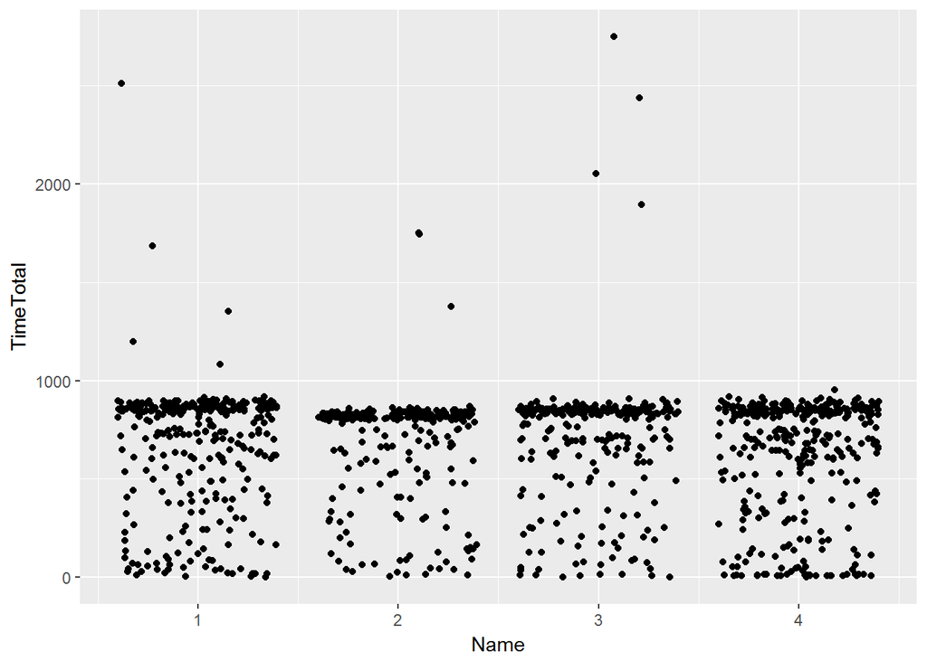

```r
KM <- DF_KM %>%
      select(Name, TimeTotal) %>%
      mutate(Name = revalue(Name, c("Machine #1" = "1", "Machine #2" = "2", "Machine #3" = "3", "Machine #4" = "4"))) %>%
      mutate(Name = as.numeric(Name))
KM  %>%
   ggplot(aes(x = Name, y = TimeTotal)) + geom_jitter()
```

What do you thinking about these points? Do you have any special thoughts? Perhaps do you see something special in the data?

```r
# Some points above level 1000 are probably either anomalies or data artefacts
# It's anyway strange that these points are never present on unit '4'
```

#### Try scaling…

run this code to perform scaling of the data and visualize them:

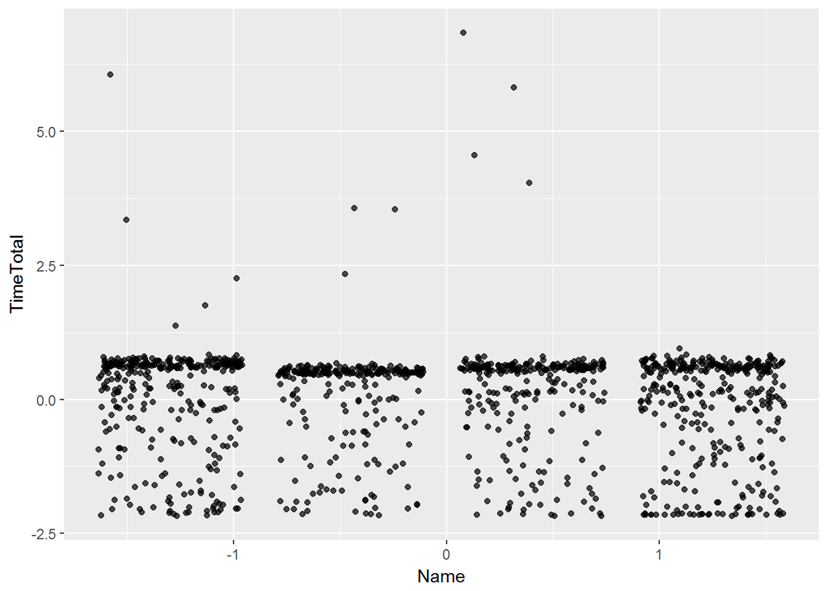

```r
# with scaling
DF_KM %>%
  select(Name, TimeTotal) %>%
  mutate(Name = revalue(Name, c("Machine #1" = "1", "Machine #2" = "2", "Machine #3" = "3", "Machine #4" = "4"))) %>%
  mutate(Name = as.numeric(Name)) %>%
  scale() %>%
  as.data.frame() %>% ggplot(aes(x = Name, y = TimeTotal)) + geom_jitter(alpha = 0.7)
```

Do you see anything different compare to the previous chart?

```r
# probably just the scale is different...
```

#### Try apply scaling in shiny!

This task probably especially intensive. Why don’t we try to add an option directly in `Shiny` that can let the user option to scale the data and directly visualize the result?

**Hint:** Add another `checkBox` in the `ui.R` with `inputId = "scaled"`

**Hint:** You can try simple **if / else** construct :)

```r
## in ui.R
# modifying tabPanel to add checkboxInput
tabPanel("Deviation Auto Detection", "Select machine step and choose the dates of interest",
           hr(),
           column(4, selectInput(inputId = "Step",label = "ChooseStep", choices = stepsChoices,
                       selected = stepsChoices[1], multiple = FALSE,
                       selectize = TRUE, size = NULL)),
           column(3, checkboxInput(inputId = "scaled", label = "Scale Data?", value = FALSE)), hr(),
           plotOutput(outputId = "Plot3"))

## in server.R
 # Prepare data for clustering and do clustering with if/else statement...
  DF_SUM_ALL <- reactive({

      # Data manipulation and saving to the DF_Data reactive value
      DF_KM <- DF_TEMP %>% #filter(EventText == "Step 2 SubStep 6")
        # filters for category
        filter(EventText == input$Step)

      # make intermediate dataframe
      KM1 <- DF_KM %>%
        select(Name, TimeTotal) %>%
        mutate(Name = revalue(Name, c("Machine #1" = "1", "Machine #2" = "2", "Machine #3" = "3", "Machine #4" = "4"))) %>%
        mutate(Name = as.numeric(Name))

      if(!input$scaled) {
        KM <- KM1 %>%
          kmeans(centers = 2, nstart = 20)
      } else {
        KM <- KM1 %>%
          scale() %>%
          as.data.frame() %>%
          kmeans(centers = 2, nstart = 20)
      }

      # saving clustering result to the new data frame
      vector <- as.data.frame.vector(KM$cluster)
      names(vector) <- "Clust"

      DF_SUM_ALL <- DF_KM %>%
        select(StartDateTime, TimeTotal, Name) %>%
        # join clustering result
        bind_cols(vector) %>%
        mutate(Clust = as.factor(Clust))


  })
```

#### Try and evaluate differences

Run the app and record steps that significantly alter result of clustering once scaling is performed. Overall what is your mind for the future? Will you use scaling or not… Try to explain your opinion…

```r
# Step 1 Substep 1, Step 1 Substep 3, Step 1 Substep 4 are definitely troubled with scaling. The rest is totally the same
# Unsupervised Machine Learning is known to be difficult and for that reason other methods exist such as hierarchical  clustering
# Probably in this case the data for Step 1 is completely randomly generated without any rule and for that scaling was able to 'catch' this phenomena.
# It would however be much advisable still to have the data scaled rather than not and make sure there are no outliers if possible
```